# Exploratory Analysis

## Wealth Inequalities Affecting Pet Ownership in the Seattle-Area

### Authors

Paulina Fronckiewicz - pfron@uw.edu Veronica Fula - vfula@uw.edu Riley Baerg - rbaerg@uw.edu Wenxuan Dong - wenxud@uw.edu

### Date

Winter 2022

### Abstract

Our main question is “does median household income affect the species, breed, and number of pets”? To address this concern, we will combine data from the US Census on median household income and from the City of Seattle on the number of pet licenses issued and especially look at the species and breed columns. This is important because this can reflect social and wealth inequalities in our society and show trends over time that can tell us more about how events like COVID affected people at a personal level.

### Related Work

Related Work: Some related work includes a survey done from 2020 to 2022 about various pet-related questions, such as whether they got a new pet in that year, if people spent more time with their pets due to COVID lockdown, and how worried they were about pet expenses. They also took age or generational data. They report that Millennials and Gen Z were more likely to be worried about pet-related expenses than Baby Boomers during the pandemic in 2020. The report attributes this to the pandemic impacted the economic situation of millions of people in the US, especially those with part-time or unguaranteed work. They also note that more people got pets in 2022 than in 2020 (14% vs 10%, respectively). This can potentially signify that the economic situation is improving and/or that people are in more need of companionship thanks to lockdown. This study shows that a link exists between economic factors and pet ownership and also that age can be another factor influencing our investigation that is not represented in our dataset. Bureau, U. S. C. (2021). INCOME IN THE PAST 12 MONTHS (IN 2021 INFLATION-ADJUSTED DOLLARS). Explore census data. Retrieved February 3, 2023, from https://data.census.gov/table?q=median%2Bincome&g=0400000US53%248600000 Seattle, C. of. (2023, January 25). Seattle Pet Licenses: City of seattle open data portal. Seattle Open Data. Retrieved February 3, 2023, from https://data.seattle.gov/Community/Seattle-Pet-Licenses/jguv-t9rb Statista (2022). How COVID-19 affected pet ownership in the U.S. 2020-2022 [Dataset]. Retrieved February 3, 2023, from https://www.statista.com/statistics/1191395/pet-ownership-status-due-to-covid-19-in-the-us/

### The Datasets

Dataset 1: Seattle Pet Licenses The data was found on Seattle Open Data Website: https://data.seattle.gov/Community/Seattle-Pet-Licenses/jguv-t9rb Dataset Owner - Arlene Ehrlich, Provided by: City of Seattle. This data is documented by shelters and pet stores to track on their end the transactions of animals to the public. Animals must be lawfully licensed, and therefore those records are traced to hold someone accountable for the animal. Collection of this data began due to lawful order from the Department of Finance and Administrative Services to citizens to license all cats, dogs, goats, and pigs. 43.9K Observations as of January 25, 2023. 7 Columns: License Issue Data, License Number, Animal’s Name, Species, Primary Breed, Secondary Breed, ZIP Code. To analyze this data we must consider income inequalities and the greater impact on the Seattle area. Purchasing and caring for a pet requires a significant amount of money to take care of. Some households can afford to care for multiple expensive purebred animals while some can barely afford to feed an animal saved from a shelter. How does income factor in on pet ownership and owner density in the Seattle area? Is there a preferred breed or animal based on income bracket and area code? The Seattle Pet Licensing dataset includes only four animals in the data frame due to the Department of Finance and Administrative Services only requiring licensing on those four animal-types. Obviously there are more than four animals that could possibly be considered as pets, and the animals that do not fit into that category could be either much more or much less expensive to take care of (outliers). First, take fish as an example: one measly goldfish does not require much space, time, effort, or money to take care of – a single fish bowl, maybe some decorations, and some fish pellets. Now consider a snake, it is considered proper to feed them live prey in order to train them (a reward system, and a means of training the snake not to bite humans) – just one snake may require hundreds a month! Another limitation is that the dataset does not include a Boolean column depicting if the animal is purebred or not. This is not an unsolvable problem, but knowing if the animal was purebred or not could provide more information on income inequalities. One last problem that this data set overlooks is the issue of unlicensed pet ownership. Even today people insist on selling pets under the table for discount prices so it goes without saying that criminally selling pets will be overlooked by this dataset.

Dataset 2: The data comes from an R package {zipcodeR} that can be found here: https://github.com/gavinrozzi/zipcodeR The package was created by Gavin C. Rozzi and combines various open data sources, in order to offer the highest possible benefit to researchers studying datasets collected at the level of ZIP codes. The data used in this report includes the median household income data from the Census Bureau. It was last updated on Oct 2, 2022. The Census Bureau’s Population Estimates Program produced and disseminated the official estimates of the population for the nation, states, counties, cities, and towns and estimates of housing units for states and counties. Data are collected from respondents directly (including businesses), through the censuses and surveys. The data was collected to generate regular and in-depth statistics about the country. This information is essential for the development of government initiatives, regulations, and decision-making processes. When using search_state() function in the package to get the data for Washington there are: - 733 observations (rows). - 24 features (columns). When working with this data it is important to consider privacy concerns such as if the personal information collected through the census is protected and kept confidential. Furthermore, it is crucial to consider if there is a risk of biased data collection and analysis which could lead to unequal representation or discrimination of certain groups, as well as, if the representation and accuracy is sufficient Although census data is a reliable source of information, it can include some limitations and problems. Firstly, the census can be a subject to undercounting certain populations, such as homeless individuals, immigrants, and people from marginalized communities, which could result in inaccurate representation of the population. Secondly, the quality of the data can be influenced by factors such as response error, data processing errors or measurement inaccuracies. Lastly, the non-response bias could impact the reliability of the data by providing an inaccurate representation of the population.

### Implications

Our analysis and final product could help educate people on the relationship between income and the type of pet, and more specifically, its breed. For policymakers, this project could bring about a better understanding of the economical condition of those who raise one or more pets and thus make more effective policies for Seattle, or specifically its local pet industry and pet owners as well as revise existing policies with defects. The project may also bring attention to the financial condition of those with moderate or low-incomes and a need for emotional support. For technologists and designers, the program helps them when they are formulating or workshopping products. For example, an urban planner may want to know the income of one area of people who breed a pet when planning the city. A technologist or a designer may consult the project when they are designing a product geared towards pet owners that are at a specific income level or adding a new function to an existing product.

### Limitations & Challenges

We pick the data of pet licenses and the pet owner information from the state government and there might be some pets not registered in Seattle. So the data has limitations in showing the type and number of the pet. Also, the license needs to renew for a certain period. So we can not know if the person changes pet or loses a pet, so the data is not so up-to-date in short term. Also, we pick two datasets, one is about pets and another is about the income of people. Mixing those two datasets and analyze accurately together is a challenge. We also plan to create a 2D data visualization on our website to show the data. Changing those data and processing them into charts and pictures on a website needs a huge amount of code and knowledge of coding more than we learned in this course. This could be a challenging task for us.

### Summary Information

The following is a summary for both the pet and zip code data frames:

Pet Summary:

nrow: 43908

, n_distinct_species: 4

, n_distinct_p_breeds: 340

Zipcode Summary:

nrow: 55

, n_distinct_cities: 1

, n_zipcodes: 55

, max_zip_code: 98199

, min_zip_code: 98101

### Table

| License.Issue.Date | Species | Primary.Breed | Secondary.Breed | ZIP.Code | Zipcode.name | County.Name |
| --- | --- | --- | --- | --- | --- | --- |
| December 18 2015 | Cat | Domestic Longhair | Mix | 98117 | SEATTLE, WA | KING |
| June 14 2016 | Cat | Siberian |  | 98117 | SEATTLE, WA | KING |
| August 04 2016 | Cat | Mix |  | 98121 | SEATTLE, WA | KING |
| January 27 2019 | Cat | Maine Coon | Mix | 98133 | SEATTLE, WA | KING |
| February 06 2019 | Cat | Domestic Shorthair | Mix | 98105 | SEATTLE, WA | KING |

The joined table includes only the necessary information from both of the tables. ZIP Code was the obvious join for this table as it resides in each of the data set and can be easily joined once both variables are of the same type. Instead of taking two entire columns for the city and state can be combined and the Zip Code, the state abbreviation should not be necessary either as the data is comprised of Washington residents alone. The information this table gives us is a direct link to our goal, the city of Seattle and the population density of pets in the area. Through most of this data, we can see while it includes pigs and goats, they are not prevalent/popular pets in the Seattle-area. From this table, the rest of the counties in Washington are also removed along with all of the cities in the same county as Seattle, this one county is King County. The Zip Codes in this specific portion of King County range from 98101 to 98199.

### Chart 1

We chose to display the number of pet licenses and median household income on a map to better visualize the spatial distribution of those two variables and to see if there is a spatial correlation between pet ownership and income level. The data is colored by the county with each color representing a different county in Washington State.

By mapping the number of pet licenses, we can see which areas have a higher concentration of pet owners. The map reveals that the highest count of pet licenses is in Seattle, in King County. Furthermore, mapping the median household income shows which areas have higher or lower income levels. We can see the bubbles with the median income are the largest around Seattle and surrounding areas. However, the two maps suggest there might not be any correlation between number of pet licenses and median household income. The number of pet licenses is generally quite small in other counties of Washington which is not the case with the median household which tends to be quite high outside of Seattle as well. Nevertheless, this might suggest some other trends such as people are more likely to be pet owners, or officially register their pets, in King County than in other parts of Washington.

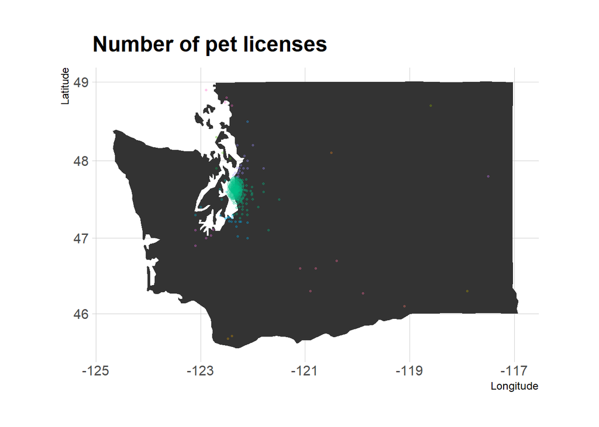

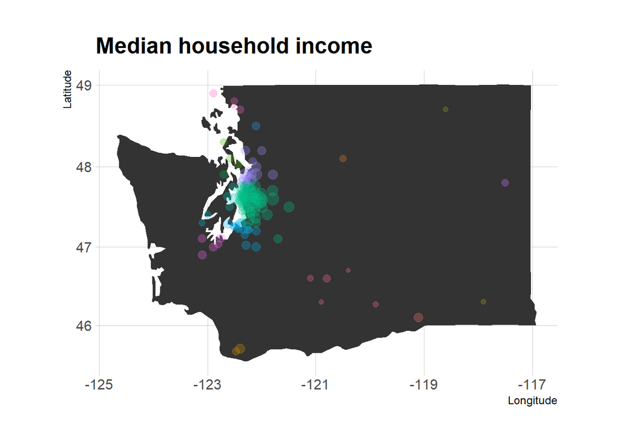

### Chart 2

The purpose of this chart is to show how the amount of pet licenses issued has changed over time, in this case a scatter plot was used to show how the amounts change every day, and then use a loess line of best fit to make it clear what the general trend is

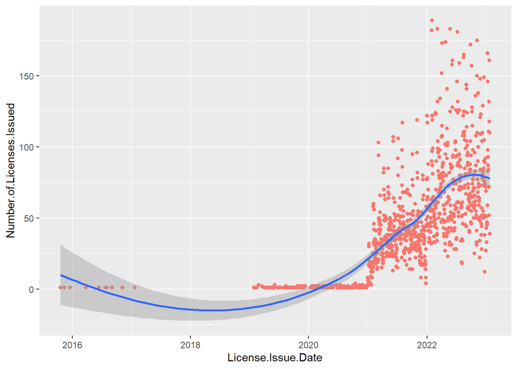

### Chart 3

I choose barplots(pie chart for additional explaination) to study the trend of species that lisence issued in Seattle area. I use the bar plot so that I can clearly see how many changes between the species from year to year through the visualization.

I divided year 2015 to 2023 into 4 parts, the first part is 2015-2020, the second part is 2021, the third part is 2022 and the fourth part is 2023. I divide the data into those four part because there is few poeple having a pet lisence from 2015 to 2020, see first plot in my charts. So I combine all the lisence issued from 2015 to 2020.  
For the trend of the pet species in time, due to what I got from the second and third plot in my visualization, I think there is no huge changes from 2015 to 2023. The ratio of dog and cat as a pet is always 7:3, which means there is 70% people who like to raise dog as a pet and 30% people who like to raise cat as a pet. So from what I learnt, people generally would like to have a dog as a pet than as a cat, ignoring some special cases such as having a pig or goat as a pet. From second plot, I noticed the most pet lisences are issued in 2021 and 2022, I think that is because covid and people need more emotional support.  
For the trend of the pet species in location, I add a csv file from https://www.downloadexcelfiles.com/us_en/download-list-zip-codes-washington-state#.Y_QW3ybMJPY in order to know the counties of each zip code. From the chart, I leartnt that in counties like Chelan, Columbia and Ferry, people tend to raise dog while in Skagit, people tend to raise cat. One thing need to notice that there is an error in the data set. Some rows leaves blank in the information about zip code while others shown N/A meaning there is no information about the zip code of the lisence.  
Also, from second plot we see that lisence for goat and pig are all given in 21 and 22. It is clear that working and studying at home makes people have a lot free time to do the things they want.

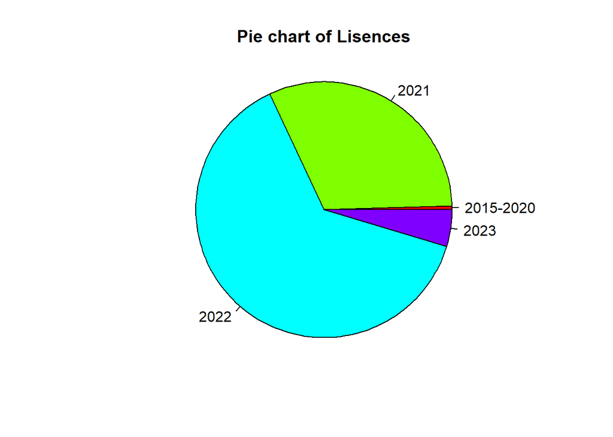

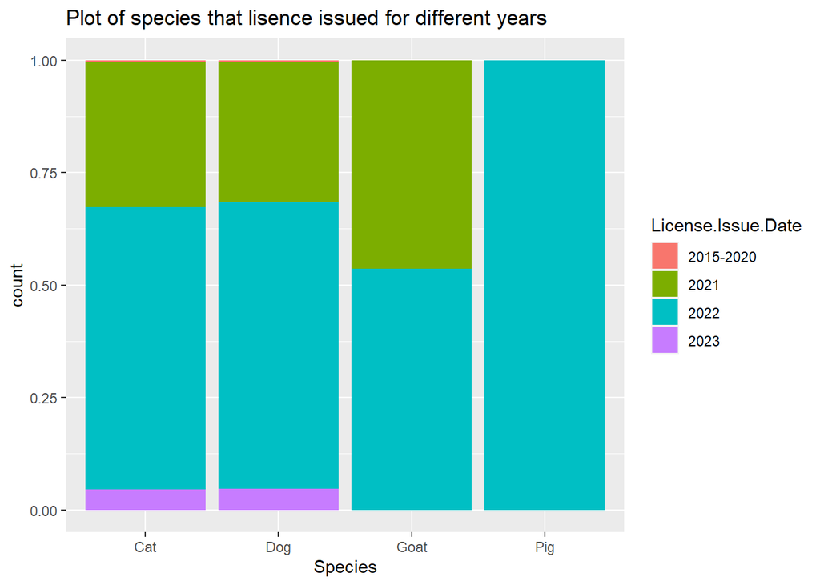

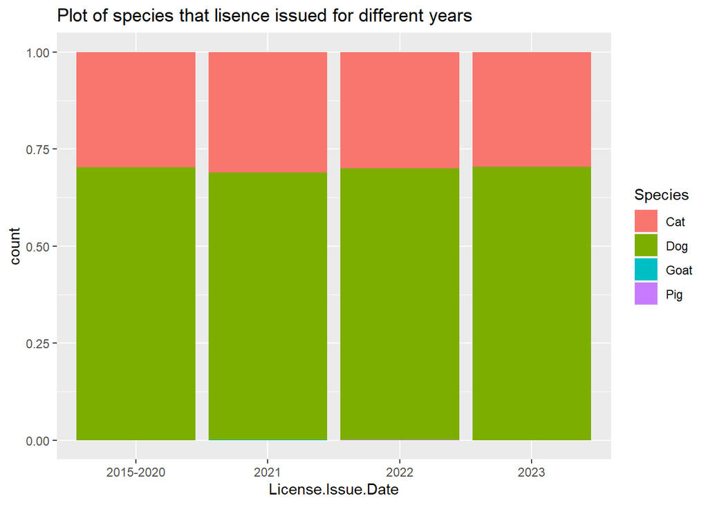

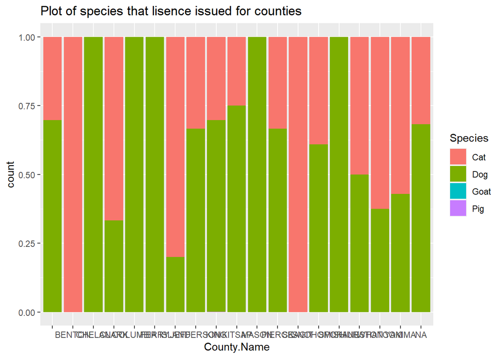